# Métodos Numéricos Aplicados a Finanças — Turma 2025

Aula 06

Prof. Frega PPGOLD/Universidade Federal do Paraná

15/04/2025

```r
library(magrittr)
.sgouttype = ifelse(!is.null(knitr::opts_knit$get("out.format")), "html", "text")
```

# 1 Chapter 6 Further Inference in Multiple Regression

```r
library(car)
```

## 1.1 6.6 Collinearity

$$y = b_0 + b_1x_1 + b_2x_2 + e\\[1em]
cor(x_1, x_2) = 0$$

Os regressores devem ser independentes, ou seja, ortogonais, não correlacionados.

banco de dados `cars`

mpg - miles per galon

cyl - número de cilindros do motor

Ou seja, quanto mais cilindros, menos milhas por galão o carro faz.

```r
data("cars", package="PoEdata")
mod1 <- lm(mpg~cyl, data=cars)
summary(mod1)
```

```
##
## Call:
## lm(formula = mpg ~ cyl, data = cars)
##
## Residuals:
##      Min       1Q   Median       3Q      Max
## -14.2413  -3.1832  -0.6332   2.5491  17.9168
##
## Coefficients:
##             Estimate Std. Error t value Pr(>|t|)
## (Intercept)  42.9155     0.8349   51.40   <2e-16 ***
## cyl          -3.5581     0.1457  -24.43   <2e-16 ***
## ---
## Signif. codes:  0 '***' 0.001 '**' 0.01 '*' 0.05 '.' 0.1 ' ' 1
##
## Residual standard error: 4.914 on 390 degrees of freedom
## Multiple R-squared:  0.6047, Adjusted R-squared:  0.6037
## F-statistic: 596.6 on 1 and 390 DF,  p-value: < 2.2e-16
```

eng - cilindrada do motor

wgt - weight (peso)

```r
mod2 <- lm(mpg~cyl+eng+wgt, data=cars)
summary(mod2)
```

```
##
## Call:
## lm(formula = mpg ~ cyl + eng + wgt, data = cars)
##
## Residuals:
##      Min       1Q   Median       3Q      Max
## -12.5568  -2.8703  -0.3649   2.2708  16.4338
##
## Coefficients:
##               Estimate Std. Error t value Pr(>|t|)
## (Intercept) 44.3709616  1.4806851  29.967  < 2e-16 ***
## cyl         -0.2677968  0.4130673  -0.648    0.517
## eng         -0.0126740  0.0082501  -1.536    0.125
## wgt         -0.0057079  0.0007139  -7.995  1.5e-14 ***
## ---
## Signif. codes:  0 '***' 0.001 '**' 0.01 '*' 0.05 '.' 0.1 ' ' 1
##
## Residual standard error: 4.297 on 388 degrees of freedom
## Multiple R-squared:  0.6993, Adjusted R-squared:  0.697
## F-statistic: 300.8 on 3 and 388 DF,  p-value: < 2.2e-16
```

Testa o VIF (Variance Inflation Factor) dos regressores

$$VIF_k = \dfrac{1}{1-R^2_k}\\[2em]
x_k = a_0 + \sum b_ix_i + e\quad \quad i\ne k$$

```r
lm(cyl~eng+wgt, data = cars) -> .m
.m %>% summary() -> .s
.s$r.squared -> .r2
1/(1-.r2)
```

```
## [1] 10.51551
```

```r
lm(eng~cyl+wgt, data = cars) -> .m
.m %>% summary() -> .s
.s$r.squared -> .r2
1/(1-.r2)
```

```
## [1] 15.78646
```

```r
lm(wgt~cyl+eng, data = cars) -> .m
.m %>% summary() -> .s
.s$r.squared -> .r2
1/(1-.r2)
```

```
## [1] 7.788716
```

```r
car::vif(mod2)
```

```
##       cyl       eng       wgt
## 10.515508 15.786455  7.788716
```

Variáveis com VIF > 10 são problemáticas e devem ser excluídas da regressão.

```r
lm(mpg~cyl+wgt, data = cars) -> .m
car::vif(.m)
```

```
##      cyl      wgt
## 5.142851 5.142851
```

```r
summary(.m)
```

```
##
## Call:
## lm(formula = mpg ~ cyl + wgt, data = cars)
##
## Residuals:
##      Min       1Q   Median       3Q      Max
## -12.6469  -2.8282  -0.2905   2.1606  16.5856
##
## Coefficients:
##               Estimate Std. Error t value Pr(>|t|)
## (Intercept) 46.2923105  0.7939685  58.305   <2e-16 ***
## cyl         -0.7213779  0.2893780  -2.493   0.0131 *
## wgt         -0.0063471  0.0005811 -10.922   <2e-16 ***
## ---
## Signif. codes:  0 '***' 0.001 '**' 0.01 '*' 0.05 '.' 0.1 ' ' 1
##
## Residual standard error: 4.304 on 389 degrees of freedom
## Multiple R-squared:  0.6975, Adjusted R-squared:  0.6959
## F-statistic: 448.4 on 2 and 389 DF,  p-value: < 2.2e-16
```

## 1.2 Omitted Variable Bias

```r
lm(mpg~cyl, data = cars) -> .m1
#car::vif(.m)
summary(.m1)
```

```
##
## Call:
## lm(formula = mpg ~ cyl, data = cars)
##
## Residuals:
##      Min       1Q   Median       3Q      Max
## -14.2413  -3.1832  -0.6332   2.5491  17.9168
##
## Coefficients:
##             Estimate Std. Error t value Pr(>|t|)
## (Intercept)  42.9155     0.8349   51.40   <2e-16 ***
## cyl          -3.5581     0.1457  -24.43   <2e-16 ***
## ---
## Signif. codes:  0 '***' 0.001 '**' 0.01 '*' 0.05 '.' 0.1 ' ' 1
##
## Residual standard error: 4.914 on 390 degrees of freedom
## Multiple R-squared:  0.6047, Adjusted R-squared:  0.6037
## F-statistic: 596.6 on 1 and 390 DF,  p-value: < 2.2e-16
```

```r
lm(mpg~wgt, data = cars) -> .m2
#car::vif(.m)
summary(.m2)
```

```
##
## Call:
## lm(formula = mpg ~ wgt, data = cars)
##
## Residuals:
##      Min       1Q   Median       3Q      Max
## -11.9736  -2.7556  -0.3358   2.1379  16.5194
##
## Coefficients:
##              Estimate Std. Error t value Pr(>|t|)
## (Intercept) 46.216524   0.798673   57.87   <2e-16 ***
## wgt         -0.007647   0.000258  -29.64   <2e-16 ***
## ---
## Signif. codes:  0 '***' 0.001 '**' 0.01 '*' 0.05 '.' 0.1 ' ' 1
##
## Residual standard error: 4.333 on 390 degrees of freedom
## Multiple R-squared:  0.6926, Adjusted R-squared:  0.6918
## F-statistic: 878.8 on 1 and 390 DF,  p-value: < 2.2e-16
```

```r
stargazer::stargazer(mod2, .m, .m1, .m2, type = .sgouttype)
```

|  | *Dependent variable:* |  |  |  |
| --- | --- | --- | --- | --- |
|  | mpg |  |  |  |
|  | (1) | (2) | (3) | (4) |
| cyl | -0.268 | -0.721** | -3.558*** |  |
|  | (0.413) | (0.289) | (0.146) |  |
| eng | -0.013 |  |  |  |
|  | (0.008) |  |  |  |
| wgt | -0.006*** | -0.006*** |  | -0.008*** |
|  | (0.001) | (0.001) |  | (0.0003) |
| Constant | 44.371*** | 46.292*** | 42.916*** | 46.217*** |
|  | (1.481) | (0.794) | (0.835) | (0.799) |
| Observations | 392 | 392 | 392 | 392 |
| R<sup>2</sup> | 0.699 | 0.697 | 0.605 | 0.693 |
| Adjusted R<sup>2</sup> | 0.697 | 0.696 | 0.604 | 0.692 |
| Residual Std. Error | 4.297 (df = 388) | 4.304 (df = 389) | 4.914 (df = 390) | 4.333 (df = 390) |
| F Statistic | 300.764*** (df = 3; 388) | 448.398*** (df = 2; 389) | 596.565*** (df = 1; 390) | 878.831*** (df = 1; 390) |
| *Note:* | p<0.1; p<0.05; p<0.01 |  |  |  |

Cuidado com a retirada de variáveis da regressão pois podemos incorrer em viés de variável omitida.

Busque sempre o equilíbrio entre o VIF e o VVO.

## 1.3 Resumo

Testar forma funcional, normalidade dos resíduos, heteroscedasticidade e inflação de variância

# 2 Chapter 8 Heteroskedasticity

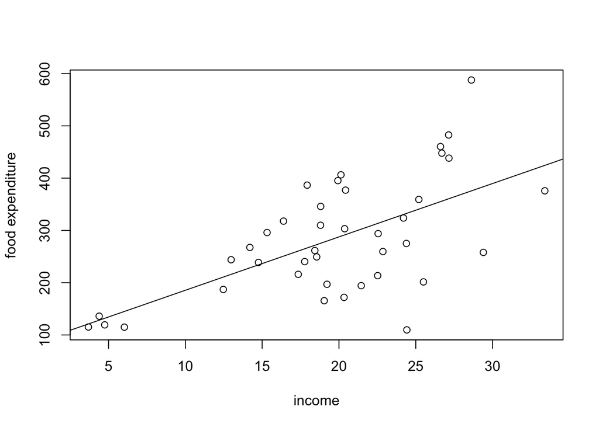

```r
data("food",package="PoEdata")
mod1 <- lm(food_exp~income, data=food)
plot(food$income,food$food_exp, type="p",
     xlab="income", ylab="food expenditure")
abline(mod1)
```

O estimador de mínimos quadrados ordinários continua sendo BLUE (best linear unbiased estimator) (consistência)

Em condição de heteroscedasticidade os erros-padrão podem ser danificados, ou seja, são mal estimados. Isso afeta a significância de cada coeficiente da regressão.

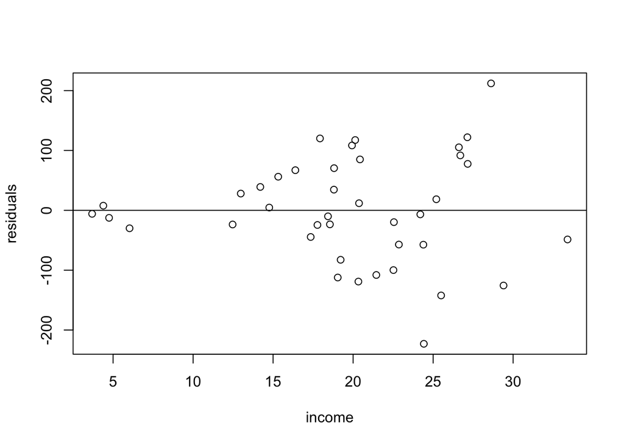

```r
res <- residuals(mod1)
yhat <- fitted(mod1)
plot(food$income,res, xlab="income", ylab="residuals")
abline(h = 0)
```

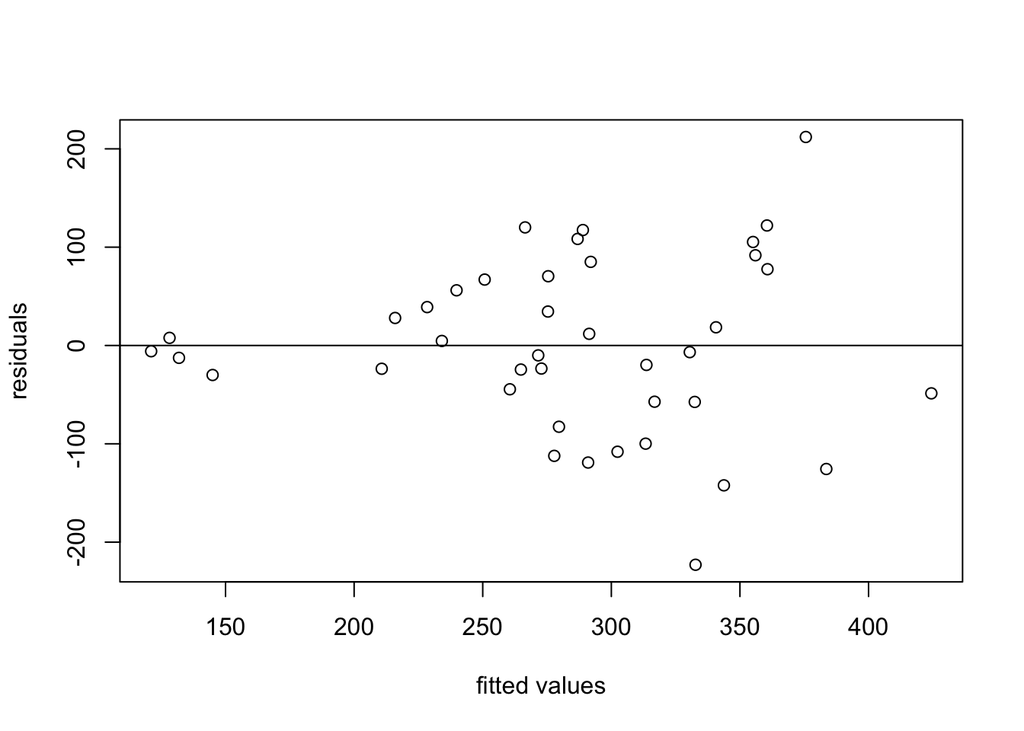

```r
plot(yhat,res, xlab="fitted values", ylab="residuals")
abline(h = 0)
```

```r
library(lmtest)
reset(mod1)
```

```
##
##  RESET test
##
## data:  mod1
## RESET = 0.066009, df1 = 2, df2 = 36, p-value = 0.9362
```

```r
shapiro.test(mod1$residuals)
```

```
##
##  Shapiro-Wilk normality test
##
## data:  mod1$residuals
## W = 0.98838, p-value = 0.9493
```

```r
# como só tenho 1 regressor não preciso fazer o teste de VIF
# H0 do teste Breusch-Pagan é que não há heteroscedasticidade (p > 0.05)
bptest(mod1)
```

```
##
##  studentized Breusch-Pagan test
##
## data:  mod1
## BP = 7.3844, df = 1, p-value = 0.006579
```

```r
summary(mod1)
```

```
##
## Call:
## lm(formula = food_exp ~ income, data = food)
##
## Residuals:
##      Min       1Q   Median       3Q      Max
## -223.025  -50.816   -6.324   67.879  212.044
##
## Coefficients:
##             Estimate Std. Error t value Pr(>|t|)
## (Intercept)   83.416     43.410   1.922   0.0622 .
## income        10.210      2.093   4.877 1.95e-05 ***
## ---
## Signif. codes:  0 '***' 0.001 '**' 0.01 '*' 0.05 '.' 0.1 ' ' 1
##
## Residual standard error: 89.52 on 38 degrees of freedom
## Multiple R-squared:  0.385,  Adjusted R-squared:  0.3688
## F-statistic: 23.79 on 1 and 38 DF,  p-value: 1.946e-05
```

## 2.1 8.3 Heteroskedasticity-Consistent Standard Errors

HC -> Heteroskedasticity-Consistent

```r
mod1
```

```
##
## Call:
## lm(formula = food_exp ~ income, data = food)
##
## Coefficients:
## (Intercept)       income
##       83.42        10.21
```

```r
library(car)
?hccm
vcov(mod1)
```

```
##             (Intercept)     income
## (Intercept)  1884.44226 -85.903157
## income        -85.90316   4.381752
```

```r
car::hccm(model = mod1) -> vcovh0
vcovh0
```

```
##             (Intercept)     income
## (Intercept)   820.87456 -50.495318
## income        -50.49532   3.557705
```

```r
library(lmtest)
summary(mod1)
```

```
##
## Call:
## lm(formula = food_exp ~ income, data = food)
##
## Residuals:
##      Min       1Q   Median       3Q      Max
## -223.025  -50.816   -6.324   67.879  212.044
##
## Coefficients:
##             Estimate Std. Error t value Pr(>|t|)
## (Intercept)   83.416     43.410   1.922   0.0622 .
## income        10.210      2.093   4.877 1.95e-05 ***
## ---
## Signif. codes:  0 '***' 0.001 '**' 0.01 '*' 0.05 '.' 0.1 ' ' 1
##
## Residual standard error: 89.52 on 38 degrees of freedom
## Multiple R-squared:  0.385,  Adjusted R-squared:  0.3688
## F-statistic: 23.79 on 1 and 38 DF,  p-value: 1.946e-05
```

```r
coeftest(mod1)
```

```
##
## t test of coefficients:
##
##             Estimate Std. Error t value  Pr(>|t|)
## (Intercept)  83.4160    43.4102  1.9216   0.06218 .
## income       10.2096     2.0933  4.8774 1.946e-05 ***
## ---
## Signif. codes:  0 '***' 0.001 '**' 0.01 '*' 0.05 '.' 0.1 ' ' 1
```

```r
coeftest(mod1, vcov. = vcovh0)
```

```
##
## t test of coefficients:
##
##             Estimate Std. Error t value  Pr(>|t|)
## (Intercept)  83.4160    28.6509  2.9115  0.005989 **
## income       10.2096     1.8862  5.4128 3.634e-06 ***
## ---
## Signif. codes:  0 '***' 0.001 '**' 0.01 '*' 0.05 '.' 0.1 ' ' 1
```

```r
coeftest(mod1, vcov. = hccm(model = mod1, type = "hc1"))
```

```
##
## t test of coefficients:
##
##             Estimate Std. Error t value  Pr(>|t|)
## (Intercept)  83.4160    27.4637  3.0373  0.004299 **
## income       10.2096     1.8091  5.6436 1.755e-06 ***
## ---
## Signif. codes:  0 '***' 0.001 '**' 0.01 '*' 0.05 '.' 0.1 ' ' 1
```

```r
coeftest(mod1, vcov. = hccm(model = mod1, type = "hc2"))
```

```
##
## t test of coefficients:
##
##             Estimate Std. Error t value  Pr(>|t|)
## (Intercept)  83.4160    27.6873  3.0128  0.004588 **
## income       10.2096     1.8234  5.5992 2.019e-06 ***
## ---
## Signif. codes:  0 '***' 0.001 '**' 0.01 '*' 0.05 '.' 0.1 ' ' 1
```

```r
coeftest(mod1, vcov. = hccm(model = mod1, type = "hc3"))
```

```
##
## t test of coefficients:
##
##             Estimate Std. Error t value  Pr(>|t|)
## (Intercept)  83.4160    28.6509  2.9115  0.005989 **
## income       10.2096     1.8862  5.4128 3.634e-06 ***
## ---
## Signif. codes:  0 '***' 0.001 '**' 0.01 '*' 0.05 '.' 0.1 ' ' 1
```

```r
coeftest(mod1, vcov. = hccm(model = mod1, type = "hc4"))
```

```
##
## t test of coefficients:
##
##             Estimate Std. Error t value  Pr(>|t|)
## (Intercept)  83.4160    28.2493  2.9528  0.005375 **
## income       10.2096     1.8537  5.5079 2.693e-06 ***
## ---
## Signif. codes:  0 '***' 0.001 '**' 0.01 '*' 0.05 '.' 0.1 ' ' 1
```

## 2.2 8.4 GLS: Known Form of Variance

$$V[e_i] = \sigma^2x_i$$

GLS = Generalized Least Squares

```r
# normalmente a compensação nos software econométricos é pelo desvio-padrão,
# ou seja, usa-se a raiz quadrada da variância, ou ainda, a raiz quadrada
# do peso.
# w = 1/sqrt(food$income)
# mas no R compensa-se pela variância, ou seja, usa-se a forma a seguir
w <- 1/food$income
food.wls <- lm(food_exp~income, weights=w, data=food)
coeftest(mod1)
```

```
##
## t test of coefficients:
##
##             Estimate Std. Error t value  Pr(>|t|)
## (Intercept)  83.4160    43.4102  1.9216   0.06218 .
## income       10.2096     2.0933  4.8774 1.946e-05 ***
## ---
## Signif. codes:  0 '***' 0.001 '**' 0.01 '*' 0.05 '.' 0.1 ' ' 1
```

```r
summary(mod1)
```

```
##
## Call:
## lm(formula = food_exp ~ income, data = food)
##
## Residuals:
##      Min       1Q   Median       3Q      Max
## -223.025  -50.816   -6.324   67.879  212.044
##
## Coefficients:
##             Estimate Std. Error t value Pr(>|t|)
## (Intercept)   83.416     43.410   1.922   0.0622 .
## income        10.210      2.093   4.877 1.95e-05 ***
## ---
## Signif. codes:  0 '***' 0.001 '**' 0.01 '*' 0.05 '.' 0.1 ' ' 1
##
## Residual standard error: 89.52 on 38 degrees of freedom
## Multiple R-squared:  0.385,  Adjusted R-squared:  0.3688
## F-statistic: 23.79 on 1 and 38 DF,  p-value: 1.946e-05
```

```r
summary(food.wls)
```

```
##
## Call:
## lm(formula = food_exp ~ income, data = food, weights = w)
##
## Weighted Residuals:
##    Min     1Q Median     3Q    Max
## -45.37 -11.13  -1.33  15.02  39.23
##
## Coefficients:
##             Estimate Std. Error t value Pr(>|t|)
## (Intercept)   78.684     23.789   3.308  0.00206 **
## income        10.451      1.386   7.541 4.61e-09 ***
## ---
## Signif. codes:  0 '***' 0.001 '**' 0.01 '*' 0.05 '.' 0.1 ' ' 1
##
## Residual standard error: 18.75 on 38 degrees of freedom
## Multiple R-squared:  0.5994, Adjusted R-squared:  0.5889
## F-statistic: 56.87 on 1 and 38 DF,  p-value: 4.614e-09
```

Estimadores GLS melhoram a eficiência da estimativa, mas não garantem a sua consistência.

Sempre vamos preferir a estimativa que mantém a consistência. Ora, como o OLS é BLUE, é sempre consistente, e será o nosso padrão de comparação.

## 2.3 8.5 Grouped Data

```r
# banco de dados cps2
data("cps2", package="PoEdata")
# faz a regressão para indivíduos fora da região metropolitana
rural.lm <- lm(wage~educ+exper, data=cps2, subset=(metro==0))
# pega-se o erro padrão da regressão
sigR <- summary(rural.lm)$sigma
# faz a regressão para indivíduos dentro da região metropolitana
metro.lm <- lm(wage~educ+exper, data=cps2, subset=(metro==1))
# pega-se o erro padrão da regressão
sigM <- summary(metro.lm)$sigma
cps2$wght <- rep(0, nrow(cps2))
# Create a vector of weights
# tenho 1000 observações na amostra
# for (i in 1:1000)
for (i in 1:nrow(cps2))
{
  if (cps2$metro[i]==0){cps2$wght[i] <- 1/sigR^2}
  else{cps2$wght[i] <- 1/sigM^2}
}
# esta estimativa pode ser inconsistente
wge.fgls <- lm(wage~educ+exper+metro, weights=wght, data=cps2)
# essas duas estimativas a seguir são OLS, portanto consistentes
wge.lm <- lm(wage~educ+exper+metro, data=cps2)
# esta estimativa, além de OLS, está compensando a heteroscedasticidade
# por Huber-White
wge.hce <- coeftest(wge.lm, vcov.=hccm(wge.lm, data=cps2))
```

```r
# apresentar as regressões em uma tabela bonitinha
library(stargazer)
stargazer(rural.lm, metro.lm, wge.lm, wge.fgls,wge.hce,
  header=FALSE,
  title="OLS vs. FGLS estimates for the 'cps2' data",
  type=.sgouttype, # "html" or "latex" (in index.Rmd)
  keep.stat="n",  # what statistics to print
  omit.table.layout="n",
  star.cutoffs=c(0.1, 0.05, 0.01, 0),
  digits=3,
#  single.row=TRUE,
  intercept.bottom=FALSE, #moves the intercept coef to top
  column.labels=c("Rural","Metro", "OLS", "FGLS", "HC1"),
  dep.var.labels.include = FALSE,
  model.numbers = FALSE,
  dep.var.caption="Dependent variable: wage",
  model.names=FALSE,
  star.char="*") #supresses the stars
```

**OLS vs. FGLS estimates for the ‘cps2’ data**

[output not shown]

### 2.3.1 Dados simulados

```r
source("https://raw.githubusercontent.com/jrfrega/2025/refs/heads/main/mhist.R")
set.seed(2)
x = MASS::mvrnorm(500, c(10, 10), Sigma = c(1, 0, 0, 1) %>% matrix(nrow = 2)) %>% round(1)
dummy = rbinom(500, 1, 0.5)
coefteorico = c(0, 4, 2, 2)
y = (cbind(1, x, dummy) %*% coefteorico + 4*rnorm(dummy, 0, dummy*2+1)) %>% round(1)
df = data.frame(y, x1 = x[,1], x2 = x[,2], dummy)
m = lm(y~x1+x2+as.factor(dummy), data = df)
reset(m)
```

```
##
##  RESET test
##
## data:  m
## RESET = 1.1301, df1 = 2, df2 = 494, p-value = 0.3238
```

```r
shapiro.test(m$residuals)
```

```
##
##  Shapiro-Wilk normality test
##
## data:  m$residuals
## W = 0.95226, p-value = 1.247e-11
```

```r
# Como o teste de Shapiro-Wilk é muito sensível para grandes amostras,
# tomamos uma subamostra para testar a normalidade dos resíduos
m$residuals %>% sample(200) %>% shapiro.test
```

```
##
##  Shapiro-Wilk normality test
##
## data:  .
## W = 0.9661, p-value = 9.588e-05
```

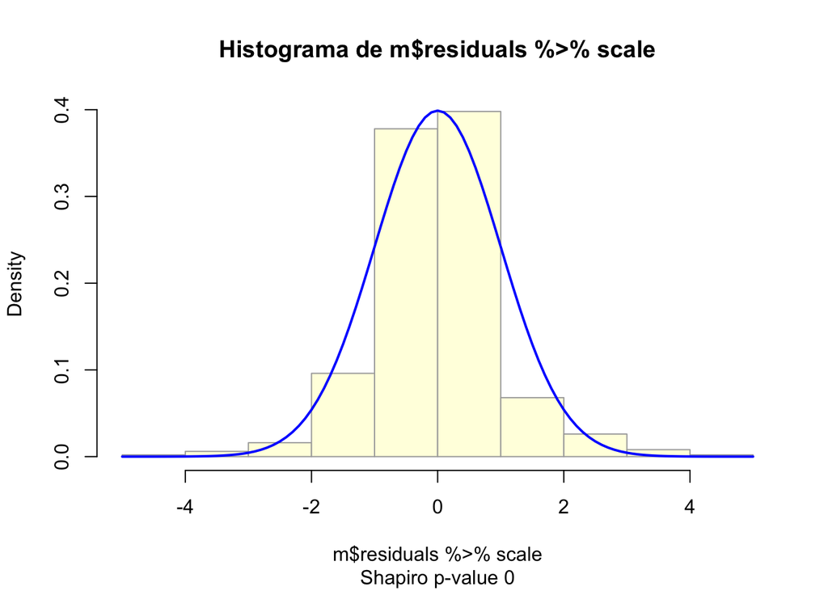

```r
# O histograma indica alguns resíduos extremos
mhist(m$residuals %>% scale)
```

```r
# Temos presença de heteroscedasticidade, isso pode
# desviar os resíduos da normalidade
bptest(m)
```

```
##
##  studentized Breusch-Pagan test
##
## data:  m
## BP = 69.622, df = 3, p-value = 5.143e-15
```

```r
# perceba que os coeficientes estão bem próximos do modelo teórico
summary(m)
```

```
##
## Call:
## lm(formula = y ~ x1 + x2 + as.factor(dummy), data = df)
##
## Residuals:
##     Min      1Q  Median      3Q     Max
## -37.175  -4.629   0.075   3.877  36.853
##
## Coefficients:
##                   Estimate Std. Error t value Pr(>|t|)
## (Intercept)         5.6414     5.4575   1.034   0.3018
## x1                  3.6680     0.3975   9.227  < 2e-16 ***
## x2                  1.7759     0.3852   4.610 5.13e-06 ***
## as.factor(dummy)1   1.9517     0.7948   2.455   0.0144 *
## ---
## Signif. codes:  0 '***' 0.001 '**' 0.01 '*' 0.05 '.' 0.1 ' ' 1
##
## Residual standard error: 8.871 on 496 degrees of freedom
## Multiple R-squared:  0.189,  Adjusted R-squared:  0.1841
## F-statistic: 38.53 on 3 and 496 DF,  p-value: < 2.2e-16
```

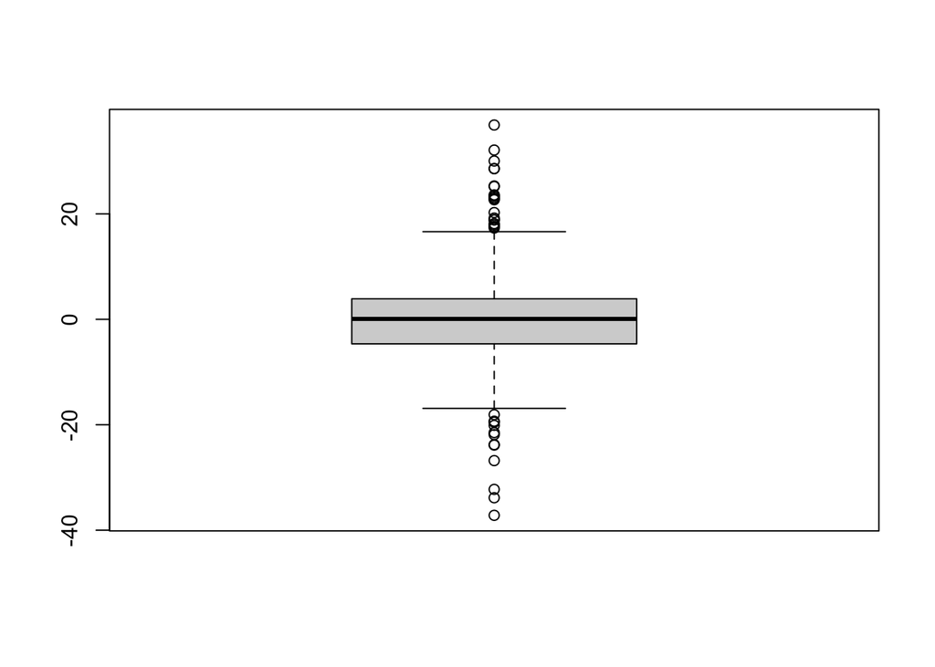

```r
# Vamos identificar os outliers (observações que geram resíduos extremos)
which(m$residuals%in%boxplot(m$residuals)$out) -> outliers
```

```r
# removemos essas observações da regressão
m = lm(y~x1+x2+as.factor(dummy), data = df[-outliers,])
reset(m)
```

```
##
##  RESET test
##
## data:  m
## RESET = 0.35555, df1 = 2, df2 = 462, p-value = 0.701
```

```r
shapiro.test(m$residuals)
```

```
##
##  Shapiro-Wilk normality test
##
## data:  m$residuals
## W = 0.98986, p-value = 0.002564
```

```r
# Passa no teste de normalidade da subamostra
m$residuals %>% sample(200) %>% shapiro.test
```

```
##
##  Shapiro-Wilk normality test
##
## data:  .
## W = 0.9864, p-value = 0.05182
```